# ProphetForecast_anyPlot_CH4_Resample3hour_Regressors-updatedSC

```python
import pandas as pd
import numpy as np
from pandas import read_excel
from pandas import DataFrame
import seaborn as sns
import matplotlib.pyplot as plt
import datetime
#from datetime import datetime
from fbprophet import Prophet
from fbprophet.plot import plot

from sklearn.metrics import mean_squared_error, mean_absolute_error
from sklearn.model_selection import ParameterGrid

from fbprophet.diagnostics import cross_validation
from fbprophet.diagnostics import performance_metrics
from fbprophet.plot import plot_cross_validation_metric

import random
import itertools
import pickle
plt.style.use('fivethirtyeight') # For plots
import os
#Author: Vatsala
```

```python
#import fbprophet
#fbprophet.__version__
```

```python
#import utils
```

```python
plot_file_path ="../prophetForecastPlots/Plot"
plot_data_path ="../plotData/"
```

```python
#### Specify Plot ID
```

```python
plotId = "1"
```

```python
#### Create directory for storing facebook prophet forecasts
```

```python
# define the name of the directory to be created for the png outputs

path_image = plot_file_path+str(plotId)

try:
    if not os.path.exists(path_image):
         os.mkdir(path_image)
except OSError:
    print ("Creation of the directory %s failed" % path_image)
else:
    print ("Successfully created the directory %s " % path_image)
```

```
Successfully created the directory ../prophetForecastPlots/Plot1
```

```python
#****** Running Forecast for Plot 1 *******  Note: Data has been QC-ed

#read Plot 1 data
data = read_excel('../plotData/Plot'+plotId+'/CH4_InterResamp3hour.xlsx', sheet_name='Sheet1')    #index_col=13, parse_dates=[13]
```

```python
#print(data.head(10))
data.dtypes
```

```
             DateTime        Flux
0 2019-03-26 15:00:00  -98.013000
1 2019-03-26 18:00:00  -61.782600
2 2019-03-26 21:00:00  -25.552200
3 2019-03-27 00:00:00  -35.076767
4 2019-03-27 03:00:00  -44.601333
5 2019-03-27 06:00:00  -54.125900
6 2019-03-27 09:00:00   -8.905609
7 2019-03-27 12:00:00   36.314682
8 2019-03-27 15:00:00   81.534973
9 2019-03-27 18:00:00  126.755264
```

```
DateTime    datetime64[ns]
Flux               float64
dtype: object
```

### Read the met data (Air Parameters) - the regressors to be added

Soil heat, air temperature, relative humidity, atmospheric pressure, total precipitation

```python
metData_AirParams = read_excel('../plotData/MetData_AirParams.xlsx', sheet_name='Sheet1')


metData_AirParams['ds'] = metData_AirParams['TIMESTAMP_1_rounded']

metData_AirParams.set_index('ds', drop=True, append=False, inplace=True, verify_integrity=False)
metData_AirParams.drop('TIMESTAMP_1_rounded', axis=1, inplace=True)
#metData_AirParams
```

| ds | G_1_1_1 | G_2_1_1 | Ta_1_1_1 | RH_1_1_1 | Pa_1_1_1 | P_1_1_1 |
| --- | --- | --- | --- | --- | --- | --- |
| 2019-03-26 17:30:00 | 1.185082 | 2.853651 | 11.850 | 54.435 | 101.8 | 0.0 |
| 2019-03-27 08:30:00 | 3.637683 | 5.828328 | 7.262 | 78.595 | 102.1 | 0.0 |
| 2019-03-27 09:00:00 | 10.508773 | 12.427950 | 7.648 | 77.565 | 102.1 | 0.0 |
| 2019-03-27 09:30:00 | 20.978545 | 23.094235 | 8.465 | 75.635 | 102.1 | 0.0 |
| 2019-03-27 10:00:00 | 33.931725 | 36.153975 | 9.505 | 71.990 | 102.1 | 0.0 |
| ... | ... | ... | ... | ... | ... | ... |
| 2019-06-29 18:30:00 | 40.378545 | 18.857910 | 28.225 | 51.725 | 99.6 | 0.0 |
| 2019-06-29 19:00:00 | 27.381235 | 12.488385 | 26.360 | 57.805 | 99.6 | 0.0 |
| 2019-06-29 19:30:00 | 19.718745 | 9.545013 | 25.520 | 62.120 | 99.6 | 0.0 |
| 2019-06-29 20:00:00 | 15.548315 | 7.728118 | 24.875 | 64.130 | 99.6 | 0.0 |
| 2019-06-29 20:30:00 | 8.269362 | 3.400640 | 23.055 | 70.600 | 99.7 | 0.0 |

2004 rows × 6 columns

### Round the met data to the nearest hour to get matching timestamps with gas flux data

```python
plot_dataframe = metData_AirParams.copy()

plot_dataframe['ds'] = metData_AirParams.index
#plot_dataframe['Flux']      = data['Flux']

#round the timestamp value to nearest half hour
plot_dataframe['ds'] = plot_dataframe['ds'].dt.round('1H')

#Drop the column Timestamp - the rounded Timestamp value will be used for plotting
#plot_dataframe.reset_('ds', axis=1, inplace=True)

#Create new index
plot_dataframe.reset_index(drop=True, inplace=True)
plot_dataframe.set_index('ds', drop=True, append=False, inplace=True, verify_integrity=False)

#plot_dataframe
```

| ds | G_1_1_1 | G_2_1_1 | Ta_1_1_1 | RH_1_1_1 | Pa_1_1_1 | P_1_1_1 |
| --- | --- | --- | --- | --- | --- | --- |
| 2019-03-26 18:00:00 | 1.185082 | 2.853651 | 11.850 | 54.435 | 101.8 | 0.0 |
| 2019-03-27 08:00:00 | 3.637683 | 5.828328 | 7.262 | 78.595 | 102.1 | 0.0 |
| 2019-03-27 09:00:00 | 10.508773 | 12.427950 | 7.648 | 77.565 | 102.1 | 0.0 |
| 2019-03-27 10:00:00 | 20.978545 | 23.094235 | 8.465 | 75.635 | 102.1 | 0.0 |
| 2019-03-27 10:00:00 | 33.931725 | 36.153975 | 9.505 | 71.990 | 102.1 | 0.0 |
| ... | ... | ... | ... | ... | ... | ... |
| 2019-06-29 18:00:00 | 40.378545 | 18.857910 | 28.225 | 51.725 | 99.6 | 0.0 |
| 2019-06-29 19:00:00 | 27.381235 | 12.488385 | 26.360 | 57.805 | 99.6 | 0.0 |
| 2019-06-29 20:00:00 | 19.718745 | 9.545013 | 25.520 | 62.120 | 99.6 | 0.0 |
| 2019-06-29 20:00:00 | 15.548315 | 7.728118 | 24.875 | 64.130 | 99.6 | 0.0 |
| 2019-06-29 20:00:00 | 8.269362 | 3.400640 | 23.055 | 70.600 | 99.7 | 0.0 |

2004 rows × 6 columns

### Resampling every 3 hour

```python
resample        = plot_dataframe.resample('3H')
daily_mean_flux = resample.mean()

daily_mean_flux.to_csv('ch4_resample_3hour')
#print(daily_mean_flux)
```

```
                        G_1_1_1    G_2_1_1   Ta_1_1_1   RH_1_1_1    Pa_1_1_1  \
ds
2019-03-26 18:00:00    1.185082   2.853651  11.850000  54.435000  101.800000
2019-03-26 21:00:00         NaN        NaN        NaN        NaN         NaN
2019-03-27 00:00:00         NaN        NaN        NaN        NaN         NaN
2019-03-27 03:00:00         NaN        NaN        NaN        NaN         NaN
2019-03-27 06:00:00    3.637683   5.828328   7.262000  78.595000  102.100000
...                         ...        ...        ...        ...         ...
2019-06-29 06:00:00   40.337127  30.635999  20.045000  74.588750  100.300000
2019-06-29 09:00:00   86.951415  58.120645  25.642000  59.056000  100.160000
2019-06-29 12:00:00  114.277400  69.189192  30.784286  41.340714   99.971429
2019-06-29 15:00:00   79.878111  49.677520  31.804000  32.152000   99.740000
2019-06-29 18:00:00   30.941385  14.745622  26.689286  55.916429   99.628571

                     P_1_1_1
ds
2019-03-26 18:00:00      0.0
2019-03-26 21:00:00      NaN
2019-03-27 00:00:00      NaN
2019-03-27 03:00:00      NaN
2019-03-27 06:00:00      0.0
...                      ...
2019-06-29 06:00:00      0.0
2019-06-29 09:00:00      0.0
2019-06-29 12:00:00      0.0
2019-06-29 15:00:00      0.0
2019-06-29 18:00:00      0.0

[761 rows x 6 columns]
```

```python
metData_AirParams = daily_mean_flux
```

### Merge the metdata together with the (gas flux) plot data

```python
metData_AirParams.to_csv('metdata-ariparams1.csv')
#metData_AirParams
```

```python
#temp = metData_AirParams.interpolate(method='linear')
```

```python
#temp.to_csv('metdata-ariparams1.csv')
#temp
```

```python
df1 = data.reset_index().rename(columns={'DateTime': 'ds', 'Flux': 'y'})
df1.set_index('ds', drop=True, append=False, inplace=True, verify_integrity=False)
df1.drop('index', axis=1, inplace=True)
df1.to_csv('ch4_3hrregre11.csv')
#df1
```

```python
#df1.info()
```

```python
merged_df1 = df1.merge(metData_AirParams, left_index=True, right_index=True, how='inner')

#merged_df1
```

| ds | y | G_1_1_1 | G_2_1_1 | Ta_1_1_1 | RH_1_1_1 | Pa_1_1_1 | P_1_1_1 |
| --- | --- | --- | --- | --- | --- | --- | --- |
| 2019-03-26 18:00:00 | -61.782600 | 1.185082 | 2.853651 | 11.850000 | 54.435000 | 101.800000 | 0.0 |
| 2019-03-26 21:00:00 | -25.552200 | NaN | NaN | NaN | NaN | NaN | NaN |
| 2019-03-27 00:00:00 | -35.076767 | NaN | NaN | NaN | NaN | NaN | NaN |
| 2019-03-27 03:00:00 | -44.601333 | NaN | NaN | NaN | NaN | NaN | NaN |
| 2019-03-27 06:00:00 | -54.125900 | 3.637683 | 5.828328 | 7.262000 | 78.595000 | 102.100000 | 0.0 |
| ... | ... | ... | ... | ... | ... | ... | ... |
| 2019-06-29 06:00:00 | 3393.950867 | 40.337127 | 30.635999 | 20.045000 | 74.588750 | 100.300000 | 0.0 |
| 2019-06-29 09:00:00 | 1639.499833 | 86.951415 | 58.120645 | 25.642000 | 59.056000 | 100.160000 | 0.0 |
| 2019-06-29 12:00:00 | -114.951200 | 114.277400 | 69.189192 | 30.784286 | 41.340714 | 99.971429 | 0.0 |
| 2019-06-29 15:00:00 | -74.633900 | 79.878111 | 49.677520 | 31.804000 | 32.152000 | 99.740000 | 0.0 |
| 2019-06-29 18:00:00 | 26.288600 | 30.941385 | 14.745622 | 26.689286 | 55.916429 | 99.628571 | 0.0 |

761 rows × 7 columns

#### There are missing values in the dataset - which can be replaced using Interpolation

(provided there is not a large gap between the timestamps)

### Removing the missing values

```python
merged_df1 = merged_df1.dropna()
```

```python
#merged_df1
```

| ds | y | G_1_1_1 | G_2_1_1 | Ta_1_1_1 | RH_1_1_1 | Pa_1_1_1 | P_1_1_1 |
| --- | --- | --- | --- | --- | --- | --- | --- |
| 2019-03-26 18:00:00 | -61.782600 | 1.185082 | 2.853651 | 11.850000 | 54.435000 | 101.800000 | 0.0 |
| 2019-03-27 06:00:00 | -54.125900 | 3.637683 | 5.828328 | 7.262000 | 78.595000 | 102.100000 | 0.0 |
| 2019-03-27 09:00:00 | -8.905609 | 31.493694 | 33.204311 | 9.236600 | 71.119000 | 102.100000 | 0.0 |
| 2019-03-27 12:00:00 | 36.314682 | 47.344952 | 51.298685 | 11.238571 | 60.707857 | 102.114286 | 0.0 |
| 2019-03-27 15:00:00 | 81.534973 | 11.433241 | 23.196786 | 12.142000 | 59.275000 | 102.080000 | 0.0 |
| ... | ... | ... | ... | ... | ... | ... | ... |
| 2019-06-29 06:00:00 | 3393.950867 | 40.337127 | 30.635999 | 20.045000 | 74.588750 | 100.300000 | 0.0 |
| 2019-06-29 09:00:00 | 1639.499833 | 86.951415 | 58.120645 | 25.642000 | 59.056000 | 100.160000 | 0.0 |
| 2019-06-29 12:00:00 | -114.951200 | 114.277400 | 69.189192 | 30.784286 | 41.340714 | 99.971429 | 0.0 |
| 2019-06-29 15:00:00 | -74.633900 | 79.878111 | 49.677520 | 31.804000 | 32.152000 | 99.740000 | 0.0 |
| 2019-06-29 18:00:00 | 26.288600 | 30.941385 | 14.745622 | 26.689286 | 55.916429 | 99.628571 | 0.0 |

434 rows × 7 columns

### Add Regressors to the model

#### Split the merged dataset into training and test set on Resampled Dataset

```python
#Train Test - split data
split_date = '31-May-2019'   #'30-April-2019'

#dataf = daily_mean_flux

mergeddf_train_gas = merged_df1.loc[merged_df1.index <= split_date].copy()
mergeddf_test_gas  = merged_df1.loc[merged_df1.index > split_date].copy()

mergeddf_train_gas.reset_index(inplace=True)
mergeddf_test_gas.reset_index(inplace=True)
#print(mergeddf_test_CO2dry.head(10))
#print(mergeddf_train_CO2dry.head(10))
```

```python
#mergeddf_train_gas
```

|  | ds | y | G_1_1_1 | G_2_1_1 | Ta_1_1_1 | RH_1_1_1 | Pa_1_1_1 | P_1_1_1 |
| --- | --- | --- | --- | --- | --- | --- | --- | --- |
| 0 | 2019-03-26 18:00:00 | -61.782600 | 1.185082 | 2.853651 | 11.850000 | 54.435000 | 101.800000 | 0.0 |
| 1 | 2019-03-27 06:00:00 | -54.125900 | 3.637683 | 5.828328 | 7.262000 | 78.595000 | 102.100000 | 0.0 |
| 2 | 2019-03-27 09:00:00 | -8.905609 | 31.493694 | 33.204311 | 9.236600 | 71.119000 | 102.100000 | 0.0 |
| 3 | 2019-03-27 12:00:00 | 36.314682 | 47.344952 | 51.298685 | 11.238571 | 60.707857 | 102.114286 | 0.0 |
| 4 | 2019-03-27 15:00:00 | 81.534973 | 11.433241 | 23.196786 | 12.142000 | 59.275000 | 102.080000 | 0.0 |
| ... | ... | ... | ... | ... | ... | ... | ... | ... |
| 286 | 2019-05-30 06:00:00 | -168.846623 | 19.984561 | 26.148229 | 15.922000 | 80.873000 | 100.560000 | 0.0 |
| 287 | 2019-05-30 09:00:00 | -168.181392 | 55.089994 | 63.503718 | 18.513000 | 75.493000 | 100.640000 | 0.0 |
| 288 | 2019-05-30 12:00:00 | -167.516162 | 55.239469 | 59.801368 | 20.570000 | 63.662857 | 100.700000 | 0.0 |
| 289 | 2019-05-30 15:00:00 | -166.850931 | 38.154175 | 39.154232 | 20.152000 | 59.942000 | 100.800000 | 0.0 |
| 290 | 2019-05-30 18:00:00 | -166.185700 | 16.685797 | 12.604126 | 18.843333 | 65.078333 | 100.800000 | 0.0 |

291 rows × 8 columns

```python
pro_regressor = Prophet()  #add tuning parameters later
pro_regressor.add_regressor('G_1_1_1')
pro_regressor.add_regressor('G_2_1_1')
pro_regressor.add_regressor('Ta_1_1_1')
pro_regressor.add_regressor('RH_1_1_1')
pro_regressor.add_regressor('Pa_1_1_1')
pro_regressor.add_regressor('P_1_1_1')

#Fitting the data
pro_regressor.fit(mergeddf_train_gas)

#future_data = pro_regressor.make_future_dataframe(periods=14, freq='D')

#forecast the data for Test  data
forecast_data1 = pro_regressor.predict(mergeddf_test_gas)
```

```
INFO:fbprophet:Disabling yearly seasonality. Run prophet with yearly_seasonality=True to override this.
```

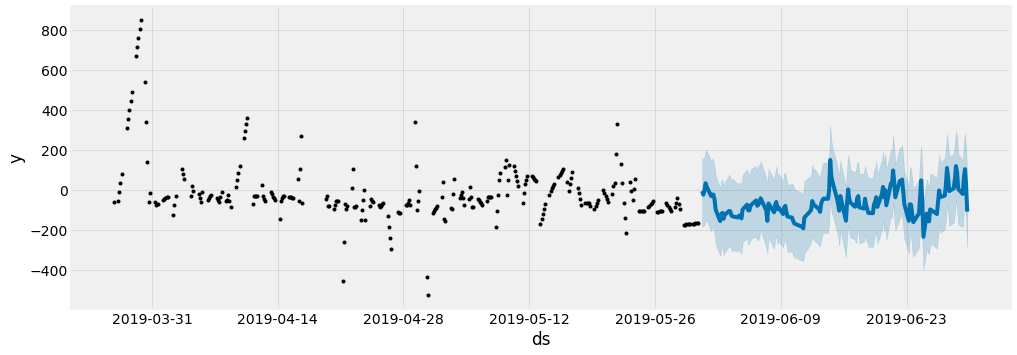

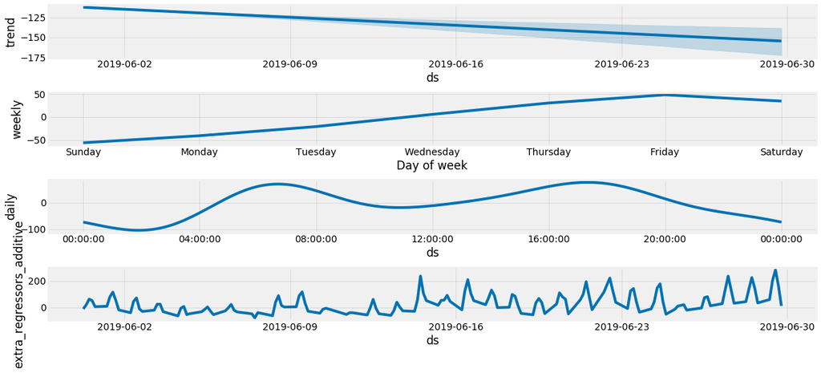

```python
fig21 = pro_regressor.plot(forecast_data1);
fig22 = pro_regressor.plot_components(forecast_data1)

fig21.set_figheight(5)
fig21.set_figwidth(15)

fig22.set_figheight(7)
fig22.set_figwidth(19)
```

### Compare the gas flux in test set and in forecasted set

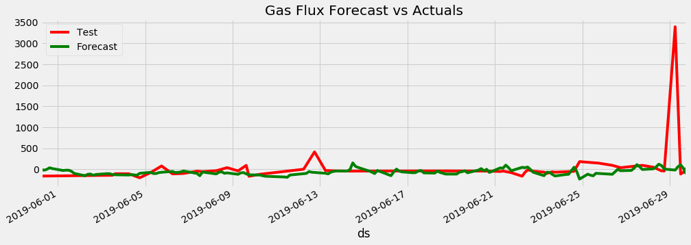

```python
df1=mergeddf_test_gas

f, ax = plt.subplots(figsize=(14,5))
f.set_figheight(5)
f.set_figwidth(15)

df1.plot(kind='line', x='ds', y='y', color='red', label='Test', ax=ax)
forecast_data1.plot(kind='line',x='ds',y='yhat', color='green',label='Forecast', ax=ax)

plt.title('Gas Flux Forecast vs Actuals')
plt.show()
```

```python
def mean_absolute_percentage_error(y_true, y_pred):
    y_true, y_pred = np.array(y_true), np.array(y_pred)
    return np.mean(np.abs((y_true - y_pred) / y_true)) * 100
```

```python
mape = mean_absolute_percentage_error(df1['y'],forecast_data1['yhat'])
print("MAPE",round(mape,4))
```

```
MAPE 588.2655
```

```python
### Try a different combination of parameters
```

```python
#pro_regressor1 = Prophet(
#    changepoint_prior_scale= 0.01,
#    changepoint_range= 0.8,
#    #n_changepoints= 125,
#    seasonality_prior_scale= 0.1,
#    seasonality_mode = 'multiplicative',
#    growth = 'linear' )

#pro_regressor1.add_regressor('G_1_1_1')
#pro_regressor1.add_regressor('G_2_1_1')
#pro_regressor1.add_regressor('Ta_1_1_1')
#pro_regressor1.add_regressor('RH_1_1_1')
#pro_regressor1.add_regressor('Pa_1_1_1')
#pro_regressor1.add_regressor('P_1_1_1')

##Fitting the data
#pro_regressor1.fit(mergeddf_train_gas)

##future_data = pro_regressor.make_future_dataframe(periods=14, freq='D')

##forecast the data for Test  data
#forecast_data2 = pro_regressor1.predict(mergeddf_test_gas)
```

```
INFO:fbprophet:Disabling yearly seasonality. Run prophet with yearly_seasonality=True to override this.
```

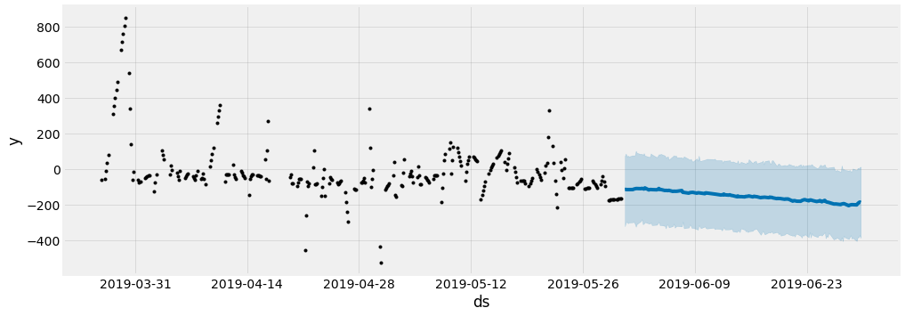

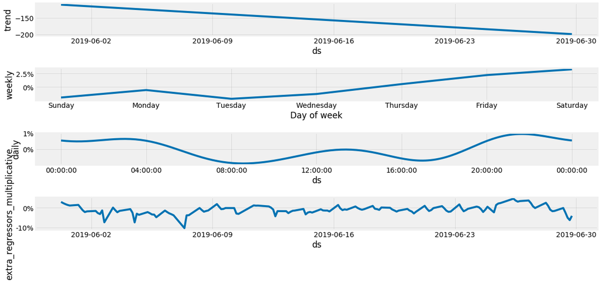

```python
#fig21 = pro_regressor1.plot(forecast_data2);
#fig22 = pro_regressor1.plot_components(forecast_data2)

#fig21.set_figheight(5)
#fig21.set_figwidth(15)

#fig22.set_figheight(7)
#fig22.set_figwidth(19)
```

```python
### Compare the gas flux in test set and in forecasted set
```

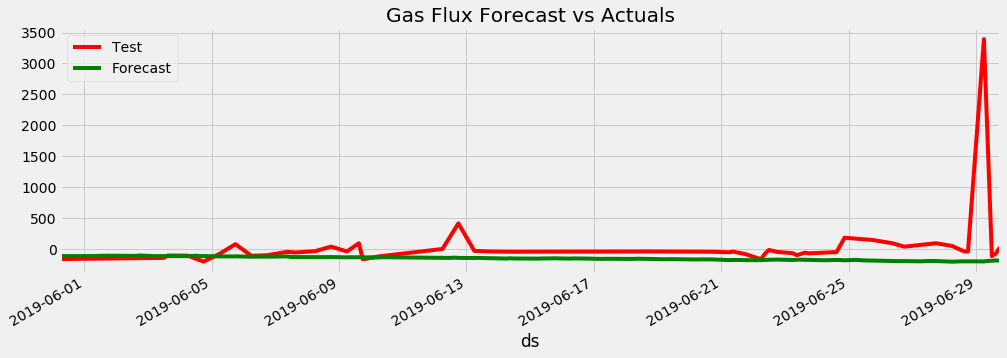

```python
#df1=mergeddf_test_gas

#f, ax = plt.subplots(figsize=(14,5))
#f.set_figheight(5)
#f.set_figwidth(15)

#df1.plot(kind='line', x='ds', y='y', color='red', label='Test', ax=ax)
#forecast_data2.plot(kind='line',x='ds',y='yhat', color='green',label='Forecast', ax=ax)#

#plt.title('Gas Flux Forecast vs Actuals')
#plt.show()
```

### Read the met data (Radiation Parameters) - the regressors to be added

```python
metData_RadiationParams = read_excel('../plotData/MetData_Radiation_Filtered.xlsx', sheet_name='Sheet1')

metData_RadiationParams['ds'] = metData_RadiationParams['TIMESTAMP_1_rounded']

metData_RadiationParams.set_index('ds', drop=True, append=False, inplace=True, verify_integrity=False)
metData_RadiationParams.drop('TIMESTAMP_1_rounded', axis=1, inplace=True)
#metData_RadiationParams
```

| ds | PPFD_1_1_1 | SWin_1_1_1 | SWout_1_1_1 | LWin_1_1_1 | LWout_1_1_1 | Rnet_1_1_1 |
| --- | --- | --- | --- | --- | --- | --- |
| 2019-03-26 17:30:00 | 277.500 | 146.150 | 33.1400 | 267.10 | 366.25 | 13.8600 |
| 2019-03-27 07:00:00 | 39.675 | 17.385 | 3.3865 | 335.05 | 345.65 | 3.3985 |
| 2019-03-27 07:30:00 | 83.325 | 37.465 | 7.3125 | 335.30 | 348.20 | 17.2525 |
| 2019-03-27 08:00:00 | 144.350 | 65.875 | 12.9050 | 335.80 | 351.85 | 36.9200 |
| 2019-03-27 08:30:00 | 220.750 | 102.000 | 20.0100 | 336.25 | 355.50 | 62.7400 |
| ... | ... | ... | ... | ... | ... | ... |
| 2019-06-29 16:30:00 | 1164.500 | 504.800 | 115.0500 | 374.70 | 495.45 | 269.0000 |
| 2019-06-29 17:00:00 | 823.950 | 342.450 | 79.0250 | 381.35 | 484.10 | 160.6750 |
| 2019-06-29 17:30:00 | 791.450 | 332.350 | 78.8700 | 388.65 | 479.85 | 162.2800 |
| 2019-06-29 18:00:00 | 619.300 | 265.350 | 64.5200 | 383.90 | 473.50 | 111.2300 |
| 2019-06-29 18:30:00 | 452.600 | 193.100 | 50.4350 | 380.05 | 465.70 | 57.0150 |

2410 rows × 6 columns

### Round the met data to the nearest hour to get matching timestamps with gas flux data

```python
plot_dataframe1 = metData_RadiationParams.copy()

plot_dataframe1['ds'] = metData_RadiationParams.index

#round the timestamp value to nearest half hour
plot_dataframe1['ds'] = plot_dataframe1['ds'].dt.round('1H')

#Create new index
plot_dataframe1.reset_index(drop=True, inplace=True)
plot_dataframe1.set_index('ds', drop=True, append=False, inplace=True, verify_integrity=False)

#plot_dataframe1
```

| ds | PPFD_1_1_1 | SWin_1_1_1 | SWout_1_1_1 | LWin_1_1_1 | LWout_1_1_1 | Rnet_1_1_1 |
| --- | --- | --- | --- | --- | --- | --- |
| 2019-03-26 18:00:00 | 277.500 | 146.150 | 33.1400 | 267.10 | 366.25 | 13.8600 |
| 2019-03-27 07:00:00 | 39.675 | 17.385 | 3.3865 | 335.05 | 345.65 | 3.3985 |
| 2019-03-27 08:00:00 | 83.325 | 37.465 | 7.3125 | 335.30 | 348.20 | 17.2525 |
| 2019-03-27 08:00:00 | 144.350 | 65.875 | 12.9050 | 335.80 | 351.85 | 36.9200 |
| 2019-03-27 08:00:00 | 220.750 | 102.000 | 20.0100 | 336.25 | 355.50 | 62.7400 |
| ... | ... | ... | ... | ... | ... | ... |
| 2019-06-29 16:00:00 | 1164.500 | 504.800 | 115.0500 | 374.70 | 495.45 | 269.0000 |
| 2019-06-29 17:00:00 | 823.950 | 342.450 | 79.0250 | 381.35 | 484.10 | 160.6750 |
| 2019-06-29 18:00:00 | 791.450 | 332.350 | 78.8700 | 388.65 | 479.85 | 162.2800 |
| 2019-06-29 18:00:00 | 619.300 | 265.350 | 64.5200 | 383.90 | 473.50 | 111.2300 |
| 2019-06-29 18:00:00 | 452.600 | 193.100 | 50.4350 | 380.05 | 465.70 | 57.0150 |

2410 rows × 6 columns

### Resampling every 3 hour

```python
resample1        = plot_dataframe1.resample('3H')
daily_mean_flux1 = resample1.mean()

print(daily_mean_flux1)
```

```
                      PPFD_1_1_1  SWin_1_1_1  SWout_1_1_1  LWin_1_1_1  \
ds
2019-03-26 18:00:00   277.500000  146.150000    33.140000  267.100000
2019-03-26 21:00:00          NaN         NaN          NaN         NaN
2019-03-27 00:00:00          NaN         NaN          NaN         NaN
2019-03-27 03:00:00          NaN         NaN          NaN         NaN
2019-03-27 06:00:00   122.025000   55.681250    10.903500  335.600000
...                          ...         ...          ...         ...
2019-06-29 06:00:00   732.928571  325.978571    82.479286  332.250000
2019-06-29 09:00:00  1708.900000  781.660000   161.890000  340.610000
2019-06-29 12:00:00  1957.500000  902.214286   167.771429  363.421429
2019-06-29 15:00:00  1324.490000  584.310000   125.905000  371.940000
2019-06-29 18:00:00   621.116667  263.600000    64.608333  384.200000

                     LWout_1_1_1  Rnet_1_1_1
ds
2019-03-26 18:00:00   366.250000   13.860000
2019-03-26 21:00:00          NaN         NaN
2019-03-27 00:00:00          NaN         NaN
2019-03-27 03:00:00          NaN         NaN
2019-03-27 06:00:00   350.300000   30.077750
...                          ...         ...
2019-06-29 06:00:00   417.171429  158.577857
2019-06-29 09:00:00   475.520000  484.860000
2019-06-29 12:00:00   507.092857  590.771429
2019-06-29 15:00:00   500.150000  330.195000
2019-06-29 18:00:00   473.016667  110.175000

[761 rows x 6 columns]
```

### Merge the Radiation metdata together with the (gas flux) plot data

```python
metData_RadiationParams = daily_mean_flux1
```

```python
metData_RadiationParams.to_csv('metdata-airparams1.csv')
#metData_RadiationParams
```

| ds | PPFD_1_1_1 | SWin_1_1_1 | SWout_1_1_1 | LWin_1_1_1 | LWout_1_1_1 | Rnet_1_1_1 |
| --- | --- | --- | --- | --- | --- | --- |
| 2019-03-26 18:00:00 | 277.500000 | 146.150000 | 33.140000 | 267.100000 | 366.250000 | 13.860000 |
| 2019-03-26 21:00:00 | NaN | NaN | NaN | NaN | NaN | NaN |
| 2019-03-27 00:00:00 | NaN | NaN | NaN | NaN | NaN | NaN |
| 2019-03-27 03:00:00 | NaN | NaN | NaN | NaN | NaN | NaN |
| 2019-03-27 06:00:00 | 122.025000 | 55.681250 | 10.903500 | 335.600000 | 350.300000 | 30.077750 |
| ... | ... | ... | ... | ... | ... | ... |
| 2019-06-29 06:00:00 | 732.928571 | 325.978571 | 82.479286 | 332.250000 | 417.171429 | 158.577857 |
| 2019-06-29 09:00:00 | 1708.900000 | 781.660000 | 161.890000 | 340.610000 | 475.520000 | 484.860000 |
| 2019-06-29 12:00:00 | 1957.500000 | 902.214286 | 167.771429 | 363.421429 | 507.092857 | 590.771429 |
| 2019-06-29 15:00:00 | 1324.490000 | 584.310000 | 125.905000 | 371.940000 | 500.150000 | 330.195000 |
| 2019-06-29 18:00:00 | 621.116667 | 263.600000 | 64.608333 | 384.200000 | 473.016667 | 110.175000 |

761 rows × 6 columns

```python
#tempR = metData_RadiationParams.interpolate(method='linear')
```

```python
#tempR
```

```python
dfR = data.reset_index().rename(columns={'DateTime': 'ds', 'Flux': 'y'})
dfR.set_index('ds', drop=True, append=False, inplace=True, verify_integrity=False)
dfR.drop('index', axis=1, inplace=True)
#dfR
```

| ds | y |
| --- | --- |
| 2019-03-26 15:00:00 | -98.013000 |
| 2019-03-26 18:00:00 | -61.782600 |
| 2019-03-26 21:00:00 | -25.552200 |
| 2019-03-27 00:00:00 | -35.076767 |
| 2019-03-27 03:00:00 | -44.601333 |
| ... | ... |
| 2019-06-29 12:00:00 | -114.951200 |
| 2019-06-29 15:00:00 | -74.633900 |
| 2019-06-29 18:00:00 | 26.288600 |
| 2019-06-29 21:00:00 | 127.211100 |
| 2019-06-30 00:00:00 | -74.012900 |

764 rows × 1 columns

```python
merged_df_R = dfR.merge(metData_RadiationParams, left_index=True, right_index=True, how='inner')

#merged_df_R
```

| ds | y | PPFD_1_1_1 | SWin_1_1_1 | SWout_1_1_1 | LWin_1_1_1 | LWout_1_1_1 | Rnet_1_1_1 |
| --- | --- | --- | --- | --- | --- | --- | --- |
| 2019-03-26 18:00:00 | -61.782600 | 277.500000 | 146.150000 | 33.140000 | 267.100000 | 366.250000 | 13.860000 |
| 2019-03-26 21:00:00 | -25.552200 | NaN | NaN | NaN | NaN | NaN | NaN |
| 2019-03-27 00:00:00 | -35.076767 | NaN | NaN | NaN | NaN | NaN | NaN |
| 2019-03-27 03:00:00 | -44.601333 | NaN | NaN | NaN | NaN | NaN | NaN |
| 2019-03-27 06:00:00 | -54.125900 | 122.025000 | 55.681250 | 10.903500 | 335.600000 | 350.300000 | 30.077750 |
| ... | ... | ... | ... | ... | ... | ... | ... |
| 2019-06-29 06:00:00 | 3393.950867 | 732.928571 | 325.978571 | 82.479286 | 332.250000 | 417.171429 | 158.577857 |
| 2019-06-29 09:00:00 | 1639.499833 | 1708.900000 | 781.660000 | 161.890000 | 340.610000 | 475.520000 | 484.860000 |
| 2019-06-29 12:00:00 | -114.951200 | 1957.500000 | 902.214286 | 167.771429 | 363.421429 | 507.092857 | 590.771429 |
| 2019-06-29 15:00:00 | -74.633900 | 1324.490000 | 584.310000 | 125.905000 | 371.940000 | 500.150000 | 330.195000 |
| 2019-06-29 18:00:00 | 26.288600 | 621.116667 | 263.600000 | 64.608333 | 384.200000 | 473.016667 | 110.175000 |

761 rows × 7 columns

### Add Regressors to the model

#### Split the merged dataset into training and test set on Resampled Dataset

```python
#Train Test - split data
split_date = '31-May-2019'   #'30-April-2019'

#dataf = daily_mean_flux

mergeddf_train_gasRa = merged_df_R.loc[merged_df_R.index <= split_date].copy()
mergeddf_test_gasRa  = merged_df_R.loc[merged_df_R.index > split_date].copy()

mergeddf_train_gasRa.reset_index(inplace=True)
mergeddf_test_gasRa.reset_index(inplace=True)

mergeddf_train_gasRa.dropna(inplace=True)
mergeddf_test_gasRa.dropna(inplace=True)
```

```python
#merged_df_R
```

| ds | y | PPFD_1_1_1 | SWin_1_1_1 | SWout_1_1_1 | LWin_1_1_1 | LWout_1_1_1 | Rnet_1_1_1 |
| --- | --- | --- | --- | --- | --- | --- | --- |
| 2019-03-26 18:00:00 | -61.782600 | 277.500000 | 146.150000 | 33.140000 | 267.100000 | 366.250000 | 13.860000 |
| 2019-03-26 21:00:00 | -25.552200 | NaN | NaN | NaN | NaN | NaN | NaN |
| 2019-03-27 00:00:00 | -35.076767 | NaN | NaN | NaN | NaN | NaN | NaN |
| 2019-03-27 03:00:00 | -44.601333 | NaN | NaN | NaN | NaN | NaN | NaN |
| 2019-03-27 06:00:00 | -54.125900 | 122.025000 | 55.681250 | 10.903500 | 335.600000 | 350.300000 | 30.077750 |
| ... | ... | ... | ... | ... | ... | ... | ... |
| 2019-06-29 06:00:00 | 3393.950867 | 732.928571 | 325.978571 | 82.479286 | 332.250000 | 417.171429 | 158.577857 |
| 2019-06-29 09:00:00 | 1639.499833 | 1708.900000 | 781.660000 | 161.890000 | 340.610000 | 475.520000 | 484.860000 |
| 2019-06-29 12:00:00 | -114.951200 | 1957.500000 | 902.214286 | 167.771429 | 363.421429 | 507.092857 | 590.771429 |
| 2019-06-29 15:00:00 | -74.633900 | 1324.490000 | 584.310000 | 125.905000 | 371.940000 | 500.150000 | 330.195000 |
| 2019-06-29 18:00:00 | 26.288600 | 621.116667 | 263.600000 | 64.608333 | 384.200000 | 473.016667 | 110.175000 |

761 rows × 7 columns

```python
#mergeddf_train_gasRa
```

|  | ds | y | PPFD_1_1_1 | SWin_1_1_1 | SWout_1_1_1 | LWin_1_1_1 | LWout_1_1_1 | Rnet_1_1_1 |
| --- | --- | --- | --- | --- | --- | --- | --- | --- |
| 0 | 2019-03-26 18:00:00 | -61.782600 | 277.500000 | 146.150000 | 33.140000 | 267.100000 | 366.250000 | 13.860000 |
| 4 | 2019-03-27 06:00:00 | -54.125900 | 122.025000 | 55.681250 | 10.903500 | 335.600000 | 350.300000 | 30.077750 |
| 5 | 2019-03-27 09:00:00 | -8.905609 | 539.020000 | 253.120000 | 49.630000 | 335.870000 | 371.400000 | 167.960000 |
| 6 | 2019-03-27 12:00:00 | 36.314682 | 830.100000 | 385.278571 | 75.622857 | 314.028571 | 385.535714 | 238.148571 |
| 7 | 2019-03-27 15:00:00 | 81.534973 | 644.540000 | 308.530000 | 68.461000 | 274.530000 | 380.530000 | 134.069000 |
| ... | ... | ... | ... | ... | ... | ... | ... | ... |
| 516 | 2019-05-30 06:00:00 | -168.846623 | 710.192857 | 321.242857 | 68.245000 | 321.628571 | 396.500000 | 178.126429 |
| 517 | 2019-05-30 09:00:00 | -168.181392 | 1637.000000 | 750.460000 | 131.590000 | 342.910000 | 421.860000 | 539.920000 |
| 518 | 2019-05-30 12:00:00 | -167.516162 | 1562.000000 | 728.585714 | 127.928571 | 352.200000 | 430.942857 | 521.914286 |
| 519 | 2019-05-30 15:00:00 | -166.850931 | 1217.580000 | 553.510000 | 112.608000 | 345.920000 | 426.090000 | 360.732000 |
| 520 | 2019-05-30 18:00:00 | -166.185700 | 323.383333 | 153.950000 | 34.245000 | 372.133333 | 411.650000 | 80.188333 |

324 rows × 8 columns

```python
merged_df_R.to_excel('ch4_radiationparams_3h.xlsx')
```

### Create Prophet model

```python
pro_regressorR = Prophet()  #add tuning parameters later
pro_regressorR.add_regressor('PPFD_1_1_1')
pro_regressorR.add_regressor('SWin_1_1_1')
pro_regressorR.add_regressor('SWout_1_1_1')
pro_regressorR.add_regressor('LWin_1_1_1')
pro_regressorR.add_regressor('LWout_1_1_1')
pro_regressorR.add_regressor('Rnet_1_1_1')

#Fitting the data
pro_regressorR.fit(mergeddf_train_gasRa)

#future_data = pro_regressor.make_future_dataframe(periods=14, freq='D')

#forecast the data for Test  data
forecast_dataR1 = pro_regressorR.predict(mergeddf_test_gasRa)
```

```
INFO:fbprophet:Disabling yearly seasonality. Run prophet with yearly_seasonality=True to override this.
```

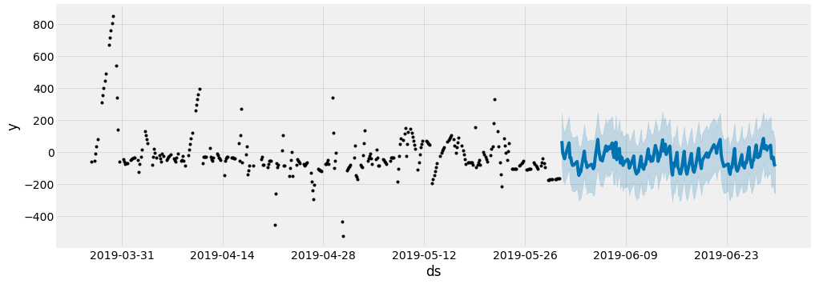

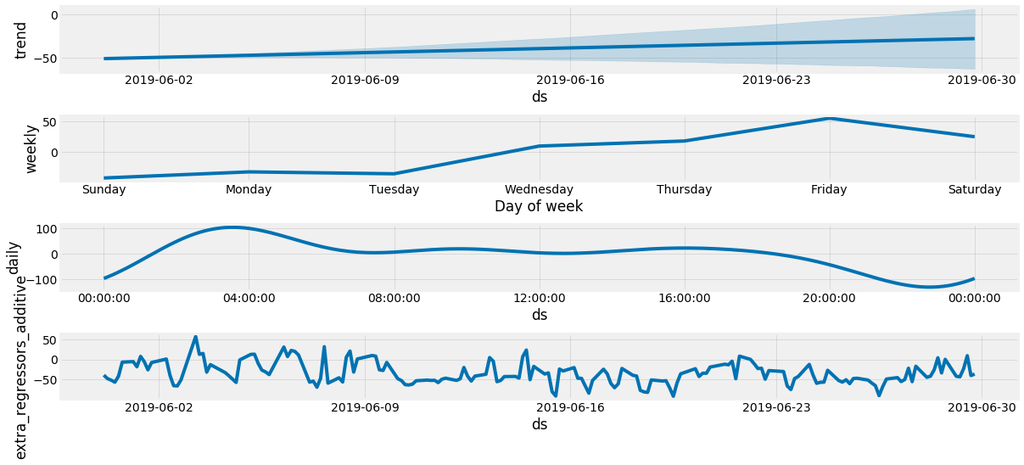

```python
fig21 = pro_regressorR.plot(forecast_dataR1);
fig22 = pro_regressorR.plot_components(forecast_dataR1)

fig21.set_figheight(5)
fig21.set_figwidth(15)

fig22.set_figheight(7)
fig22.set_figwidth(19)
```

### Measure the performance of the model¶

```python
mape = mean_absolute_percentage_error(mergeddf_test_gasRa['y'],forecast_dataR1['yhat'])
print("MAPE",round(mape,4))
```

```
MAPE 286.6108
```

### Compare the gas flux in test set and in forecasted set

```python
pd.plotting.register_matplotlib_converters()
```

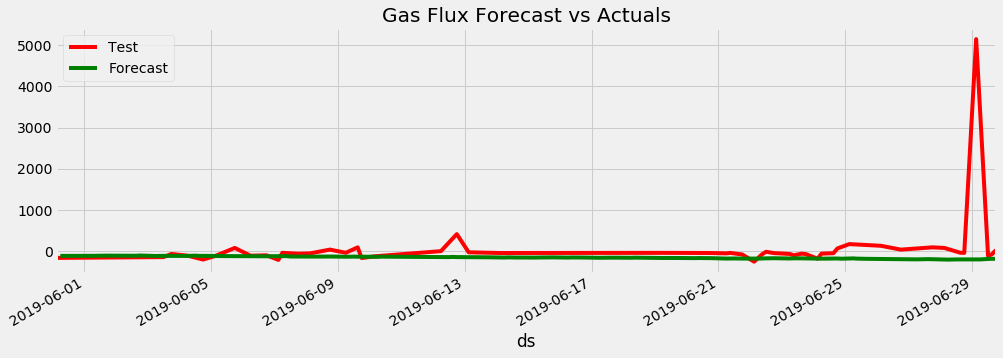

```python
df2=mergeddf_test_gasRa

f, ax = plt.subplots(figsize=(14,5))
f.set_figheight(5)
f.set_figwidth(15)

df2.plot(kind='line', x='ds', y='y', color='red', label='Test', ax=ax)
forecast_data2.plot(kind='line',x='ds',y='yhat', color='green',label='Forecast', ax=ax)

plt.title('Gas Flux Forecast vs Actuals')
plt.show()
```

### Read the met data (Soil Parameters STP) - the regressors to be added

```python
metData_SoilSTPParams = read_excel('../plotData/MetData_SoilParams_STP_Filtered.xlsx', sheet_name='Sheet1')

metData_SoilSTPParams['ds'] = metData_SoilSTPParams['TIMESTAMP_1_rounded']

metData_SoilSTPParams.set_index('ds', drop=True, append=False, inplace=True, verify_integrity=False)
metData_SoilSTPParams.drop('TIMESTAMP_1_rounded', axis=1, inplace=True)
#metData_SoilSTPParams
```

| ds | STP_TSoil_2_1_1_1 | STP_TSoil5_1_1_1 | STP_TSoil10_1_1_1 | STP_TSoil20_1_1_1 | STP_TSoil50_1_1_1 |
| --- | --- | --- | --- | --- | --- |
| 2019-03-26 17:30:00 | 8.530 | 9.120 | 11.335 | 12.255 | 12.320 |
| 2019-03-26 18:00:00 | 8.520 | 9.205 | 11.215 | 11.795 | 11.585 |
| 2019-03-26 18:30:00 | 8.510 | 9.280 | 11.040 | 11.335 | 10.905 |
| 2019-03-26 19:00:00 | 8.505 | 9.335 | 10.810 | 10.890 | 10.435 |
| 2019-03-26 19:30:00 | 8.510 | 9.385 | 10.605 | 10.575 | 10.145 |
| ... | ... | ... | ... | ... | ... |
| 2019-06-30 00:00:00 | 14.630 | 17.805 | 19.025 | 19.030 | 18.735 |
| 2019-06-30 00:30:00 | 14.645 | 17.910 | 18.945 | 18.845 | 18.480 |
| 2019-06-30 01:00:00 | 14.670 | 17.760 | 18.730 | 18.615 | 18.230 |
| 2019-06-30 01:30:00 | 14.685 | 17.730 | 18.580 | 18.405 | 17.980 |
| 2019-06-30 02:00:00 | 14.700 | 17.690 | 18.425 | 18.200 | 17.740 |

4498 rows × 5 columns

### Round the met data to the nearest hour to get matching timestamps with gas flux data

```python
plot_dataframe2 = metData_SoilSTPParams.copy()

plot_dataframe2['ds'] = metData_SoilSTPParams.index

#round the timestamp value to nearest half hour
plot_dataframe2['ds'] = plot_dataframe2['ds'].dt.round('1H')

#Create new index
plot_dataframe2.reset_index(drop=True, inplace=True)
plot_dataframe2.set_index('ds', drop=True, append=False, inplace=True, verify_integrity=False)

#plot_dataframe2
```

| ds | STP_TSoil_2_1_1_1 | STP_TSoil5_1_1_1 | STP_TSoil10_1_1_1 | STP_TSoil20_1_1_1 | STP_TSoil50_1_1_1 |
| --- | --- | --- | --- | --- | --- |
| 2019-03-26 18:00:00 | 8.530 | 9.120 | 11.335 | 12.255 | 12.320 |
| 2019-03-26 18:00:00 | 8.520 | 9.205 | 11.215 | 11.795 | 11.585 |
| 2019-03-26 18:00:00 | 8.510 | 9.280 | 11.040 | 11.335 | 10.905 |
| 2019-03-26 19:00:00 | 8.505 | 9.335 | 10.810 | 10.890 | 10.435 |
| 2019-03-26 20:00:00 | 8.510 | 9.385 | 10.605 | 10.575 | 10.145 |
| ... | ... | ... | ... | ... | ... |
| 2019-06-30 00:00:00 | 14.630 | 17.805 | 19.025 | 19.030 | 18.735 |
| 2019-06-30 00:00:00 | 14.645 | 17.910 | 18.945 | 18.845 | 18.480 |
| 2019-06-30 01:00:00 | 14.670 | 17.760 | 18.730 | 18.615 | 18.230 |
| 2019-06-30 02:00:00 | 14.685 | 17.730 | 18.580 | 18.405 | 17.980 |
| 2019-06-30 02:00:00 | 14.700 | 17.690 | 18.425 | 18.200 | 17.740 |

4498 rows × 5 columns

### Resampling every 3 hour

```python
resample2        = plot_dataframe2.resample('3H')
daily_mean_flux2 = resample2.mean()

#print(daily_mean_flux2)
```

```
                     STP_TSoil_2_1_1_1  STP_TSoil5_1_1_1  STP_TSoil10_1_1_1  \
ds
2019-03-26 18:00:00           8.512857          9.307143          10.806429
2019-03-26 21:00:00           8.501000          9.377000           9.706000
2019-03-27 00:00:00           8.519286          9.165000           8.733571
2019-03-27 03:00:00           8.543000          8.802000           7.882500
2019-03-27 06:00:00           8.559286          8.473571           7.616929
...                                ...               ...                ...
2019-06-29 12:00:00          14.473571         16.321429          19.018571
2019-06-29 15:00:00          14.479000         17.048000          20.168000
2019-06-29 18:00:00          14.507143         17.586429          20.122143
2019-06-29 21:00:00          14.577000         17.816000          19.585000
2019-06-30 00:00:00          14.658333         17.786667          18.814167

                     STP_TSoil20_1_1_1  STP_TSoil50_1_1_1
ds
2019-03-26 18:00:00          11.038571          10.717143
2019-03-26 21:00:00           9.328000           8.757000
2019-03-27 00:00:00           8.028286           7.232571
2019-03-27 03:00:00           7.201100           6.684700
2019-03-27 06:00:00           7.188214           6.954714
...                                ...                ...
2019-06-29 12:00:00          21.013571          22.800000
2019-06-29 15:00:00          21.718000          22.736000
2019-06-29 18:00:00          20.993571          21.405000
2019-06-29 21:00:00          19.903000          19.832000
2019-06-30 00:00:00          18.723333          18.360833

[763 rows x 5 columns]
```

### Merge the metdata together with the (gas flux) plot data

```python
metData_SoilSTPParams = daily_mean_flux2

metData_SoilSTPParams.to_csv('metdata-soilSTPparams.csv')
#metData_SoilSTPParams
```

| ds | STP_TSoil_2_1_1_1 | STP_TSoil5_1_1_1 | STP_TSoil10_1_1_1 | STP_TSoil20_1_1_1 | STP_TSoil50_1_1_1 |
| --- | --- | --- | --- | --- | --- |
| 2019-03-26 18:00:00 | 8.512857 | 9.307143 | 10.806429 | 11.038571 | 10.717143 |
| 2019-03-26 21:00:00 | 8.501000 | 9.377000 | 9.706000 | 9.328000 | 8.757000 |
| 2019-03-27 00:00:00 | 8.519286 | 9.165000 | 8.733571 | 8.028286 | 7.232571 |
| 2019-03-27 03:00:00 | 8.543000 | 8.802000 | 7.882500 | 7.201100 | 6.684700 |
| 2019-03-27 06:00:00 | 8.559286 | 8.473571 | 7.616929 | 7.188214 | 6.954714 |
| ... | ... | ... | ... | ... | ... |
| 2019-06-29 12:00:00 | 14.473571 | 16.321429 | 19.018571 | 21.013571 | 22.800000 |
| 2019-06-29 15:00:00 | 14.479000 | 17.048000 | 20.168000 | 21.718000 | 22.736000 |
| 2019-06-29 18:00:00 | 14.507143 | 17.586429 | 20.122143 | 20.993571 | 21.405000 |
| 2019-06-29 21:00:00 | 14.577000 | 17.816000 | 19.585000 | 19.903000 | 19.832000 |
| 2019-06-30 00:00:00 | 14.658333 | 17.786667 | 18.814167 | 18.723333 | 18.360833 |

763 rows × 5 columns

```python
#tempSTP = metData_SoilSTPParams.interpolate(method='linear')
```

```python
#tempSTP
```

```python
dfSTP = data.reset_index().rename(columns={'DateTime': 'ds', 'Flux': 'y'})
dfSTP.set_index('ds', drop=True, append=False, inplace=True, verify_integrity=False)
dfSTP.drop('index', axis=1, inplace=True)
#dfSTP
```

| ds | y |
| --- | --- |
| 2019-03-26 15:00:00 | -98.013000 |
| 2019-03-26 18:00:00 | -61.782600 |
| 2019-03-26 21:00:00 | -25.552200 |
| 2019-03-27 00:00:00 | -35.076767 |
| 2019-03-27 03:00:00 | -44.601333 |
| ... | ... |
| 2019-06-29 12:00:00 | -114.951200 |
| 2019-06-29 15:00:00 | -74.633900 |
| 2019-06-29 18:00:00 | 26.288600 |
| 2019-06-29 21:00:00 | 127.211100 |
| 2019-06-30 00:00:00 | -74.012900 |

764 rows × 1 columns

```python
merged_df_STP = dfSTP.merge(metData_SoilSTPParams, left_index=True, right_index=True, how='inner')

#merged_df_STP
```

| ds | y | STP_TSoil_2_1_1_1 | STP_TSoil5_1_1_1 | STP_TSoil10_1_1_1 | STP_TSoil20_1_1_1 | STP_TSoil50_1_1_1 |
| --- | --- | --- | --- | --- | --- | --- |
| 2019-03-26 18:00:00 | -61.782600 | 8.512857 | 9.307143 | 10.806429 | 11.038571 | 10.717143 |
| 2019-03-26 21:00:00 | -25.552200 | 8.501000 | 9.377000 | 9.706000 | 9.328000 | 8.757000 |
| 2019-03-27 00:00:00 | -35.076767 | 8.519286 | 9.165000 | 8.733571 | 8.028286 | 7.232571 |
| 2019-03-27 03:00:00 | -44.601333 | 8.543000 | 8.802000 | 7.882500 | 7.201100 | 6.684700 |
| 2019-03-27 06:00:00 | -54.125900 | 8.559286 | 8.473571 | 7.616929 | 7.188214 | 6.954714 |
| ... | ... | ... | ... | ... | ... | ... |
| 2019-06-29 12:00:00 | -114.951200 | 14.473571 | 16.321429 | 19.018571 | 21.013571 | 22.800000 |
| 2019-06-29 15:00:00 | -74.633900 | 14.479000 | 17.048000 | 20.168000 | 21.718000 | 22.736000 |
| 2019-06-29 18:00:00 | 26.288600 | 14.507143 | 17.586429 | 20.122143 | 20.993571 | 21.405000 |
| 2019-06-29 21:00:00 | 127.211100 | 14.577000 | 17.816000 | 19.585000 | 19.903000 | 19.832000 |
| 2019-06-30 00:00:00 | -74.012900 | 14.658333 | 17.786667 | 18.814167 | 18.723333 | 18.360833 |

763 rows × 6 columns

### Add Regressors to the model

#### Split the merged dataset into training and test set on Resampled Dataset

```python
#Train Test - split data
split_date = '31-May-2019'   #'30-April-2019'

#dataf = daily_mean_flux

mergeddf_train_gasSTP = merged_df_STP.loc[merged_df_STP.index <= split_date].copy()
mergeddf_test_gasSTP  = merged_df_STP.loc[merged_df_STP.index > split_date].copy()

mergeddf_train_gasSTP.reset_index(inplace=True)
mergeddf_test_gasSTP.reset_index(inplace=True)
```

```python
mergeddf_train_gasSTP.dropna(inplace=True)
mergeddf_test_gasSTP.dropna(inplace=True)
```

```python
#mergeddf_train_gasSTP
```

|  | ds | y | STP_TSoil_2_1_1_1 | STP_TSoil5_1_1_1 | STP_TSoil10_1_1_1 | STP_TSoil20_1_1_1 | STP_TSoil50_1_1_1 |
| --- | --- | --- | --- | --- | --- | --- | --- |
| 0 | 2019-03-26 18:00:00 | -61.782600 | 8.512857 | 9.307143 | 10.806429 | 11.038571 | 10.717143 |
| 1 | 2019-03-26 21:00:00 | -25.552200 | 8.501000 | 9.377000 | 9.706000 | 9.328000 | 8.757000 |
| 2 | 2019-03-27 00:00:00 | -35.076767 | 8.519286 | 9.165000 | 8.733571 | 8.028286 | 7.232571 |
| 3 | 2019-03-27 03:00:00 | -44.601333 | 8.543000 | 8.802000 | 7.882500 | 7.201100 | 6.684700 |
| 4 | 2019-03-27 06:00:00 | -54.125900 | 8.559286 | 8.473571 | 7.616929 | 7.188214 | 6.954714 |
| ... | ... | ... | ... | ... | ... | ... | ... |
| 518 | 2019-05-30 12:00:00 | -167.516162 | 12.247143 | 13.530000 | 16.035000 | 17.766429 | 19.085714 |
| 519 | 2019-05-30 15:00:00 | -166.850931 | 12.249000 | 14.195000 | 16.869000 | 18.227000 | 19.067000 |
| 520 | 2019-05-30 18:00:00 | -166.185700 | 12.273571 | 14.634286 | 16.670000 | 17.230000 | 17.301429 |
| 521 | 2019-05-30 21:00:00 | -165.520469 | 12.324000 | 14.711000 | 15.729000 | 15.655000 | 15.361000 |
| 522 | 2019-05-31 00:00:00 | -164.855238 | 12.403571 | 14.525714 | 14.987143 | 14.868571 | 14.699286 |

512 rows × 7 columns

### Create Prophet model

```python
pro_regressorSTP = Prophet()  #add tuning parameters later
pro_regressorSTP.add_regressor('STP_TSoil_2_1_1_1')
pro_regressorSTP.add_regressor('STP_TSoil5_1_1_1')
pro_regressorSTP.add_regressor('STP_TSoil10_1_1_1')
pro_regressorSTP.add_regressor('STP_TSoil20_1_1_1')
pro_regressorSTP.add_regressor('STP_TSoil50_1_1_1')

#Fitting the data
pro_regressorSTP.fit(mergeddf_train_gasSTP)

#future_data = pro_regressor.make_future_dataframe(periods=14, freq='D')

#forecast the data for Test  data
forecast_dataSTP = pro_regressorSTP.predict(mergeddf_test_gasSTP)
```

```
INFO:fbprophet:Disabling yearly seasonality. Run prophet with yearly_seasonality=True to override this.
```

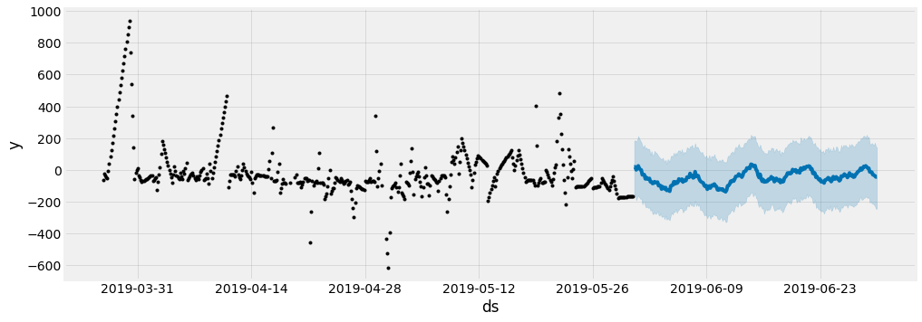

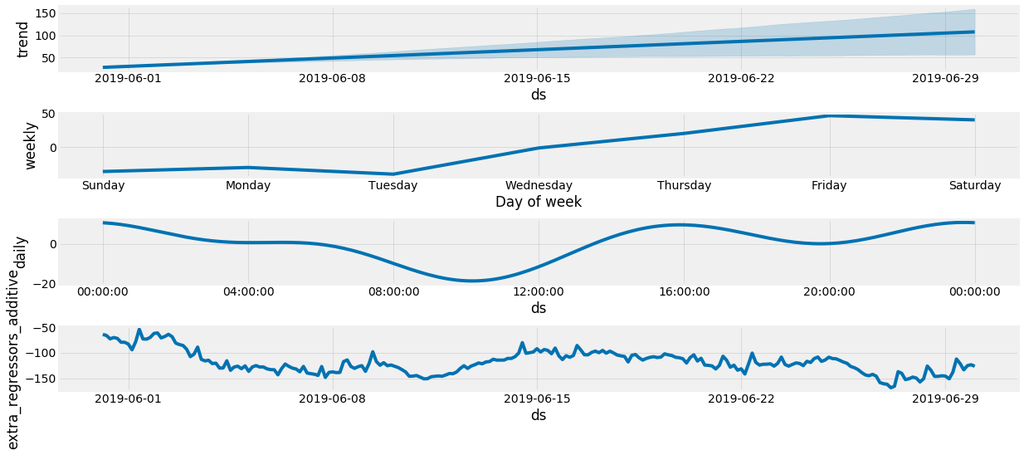

```python
fig21 = pro_regressorSTP.plot(forecast_dataSTP);
fig22 = pro_regressorSTP.plot_components(forecast_dataSTP)

fig21.set_figheight(5)
fig21.set_figwidth(15)

fig22.set_figheight(7)
fig22.set_figwidth(19)
```

```python
forecast_dataSTP
```

|  | ds | trend | yhat_lower | yhat_upper | trend_lower | trend_upper | STP_TSoil10_1_1_1 | STP_TSoil10_1_1_1_lower | STP_TSoil10_1_1_1_upper | STP_TSoil20_1_1_1 | ... | extra_regressors_additive | extra_regressors_additive_lower | extra_regressors_additive_upper | weekly | weekly_lower | weekly_upper | multiplicative_terms | multiplicative_terms_lower | multiplicative_terms_upper | yhat |
| --- | --- | --- | --- | --- | --- | --- | --- | --- | --- | --- | --- | --- | --- | --- | --- | --- | --- | --- | --- | --- | --- |
| 0 | 2019-05-31 03:00:00 | 28.159605 | -162.523232 | 184.113386 | 28.159605 | 28.159605 | -123.987187 | -123.987187 | -123.987187 | -92.493362 | ... | -64.267747 | -64.267747 | -64.267747 | 52.469474 | 52.469474 | 52.469474 | 0.0 | 0.0 | 0.0 | 17.982053 |
| 1 | 2019-05-31 06:00:00 | 28.492292 | -153.401803 | 185.431974 | 28.492292 | 28.492292 | -119.755214 | -119.755214 | -119.755214 | -95.097673 | ... | -66.238605 | -66.238605 | -66.238605 | 56.918136 | 56.918136 | 56.918136 | 0.0 | 0.0 | 0.0 | 18.980162 |
| 2 | 2019-05-31 09:00:00 | 28.824980 | -192.697526 | 177.252546 | 28.824980 | 28.824980 | -129.960857 | -129.960857 | -129.960857 | -110.300237 | ... | -72.830993 | -72.830993 | -72.830993 | 59.836792 | 59.836792 | 59.836792 | 0.0 | 0.0 | 0.0 | 0.049194 |
| 3 | 2019-05-31 12:00:00 | 29.157668 | -172.278376 | 189.363948 | 29.157668 | 29.157668 | -146.180094 | -146.180094 | -146.180094 | -130.312310 | ... | -70.263520 | -70.263520 | -70.263520 | 60.757860 | 60.757860 | 60.757860 | 0.0 | 0.0 | 0.0 | 8.075401 |
| 4 | 2019-05-31 15:00:00 | 29.490356 | -161.955527 | 213.345319 | 29.490356 | 29.490356 | -168.108503 | -168.108503 | -168.108503 | -152.150626 | ... | -72.003369 | -72.003369 | -72.003369 | 59.355231 | 59.355231 | 59.355231 | 0.0 | 0.0 | 0.0 | 25.193020 |
| ... | ... | ... | ... | ... | ... | ... | ... | ... | ... | ... | ... | ... | ... | ... | ... | ... | ... | ... | ... | ... | ... |
| 235 | 2019-06-29 12:00:00 | 106.341232 | -211.565842 | 161.305550 | 56.784145 | 156.013424 | -279.776702 | -279.776702 | -279.776702 | -276.673775 | ... | -121.266053 | -121.266053 | -121.266053 | -3.982414 | -3.982414 | -3.982414 | 0.0 | 0.0 | 0.0 | -30.483841 |
| 236 | 2019-06-29 15:00:00 | 106.673920 | -218.895135 | 154.329101 | 56.726688 | 156.828677 | -319.930543 | -319.930543 | -319.930543 | -296.552811 | ... | -133.469544 | -133.469544 | -133.469544 | -14.619454 | -14.619454 | -14.619454 | 0.0 | 0.0 | 0.0 | -33.064276 |
| 237 | 2019-06-29 18:00:00 | 107.006608 | -226.024869 | 171.000276 | 56.821482 | 157.626548 | -318.328581 | -318.328581 | -318.328581 | -276.109374 | ... | -125.257996 | -125.257996 | -125.257996 | -23.808051 | -23.808051 | -23.808051 | 0.0 | 0.0 | 0.0 | -37.835669 |
| 238 | 2019-06-29 21:00:00 | 107.339296 | -244.146184 | 148.747362 | 56.985238 | 158.420452 | -299.564171 | -299.564171 | -299.564171 | -245.333353 | ... | -123.514882 | -123.514882 | -123.514882 | -31.138743 | -31.138743 | -31.138743 | 0.0 | 0.0 | 0.0 | -44.780285 |
| 239 | 2019-06-30 00:00:00 | 107.671983 | -245.355023 | 139.870545 | 56.837485 | 159.155250 | -272.636079 | -272.636079 | -272.636079 | -212.043057 | ... | -126.363533 | -126.363533 | -126.363533 | -36.384887 | -36.384887 | -36.384887 | 0.0 | 0.0 | 0.0 | -44.255920 |

240 rows × 37 columns

### Measure the performance of the model

```python
mape = mean_absolute_percentage_error(mergeddf_test_gasSTP['y'],forecast_dataSTP['yhat'])
print("MAPE",round(mape,4))
```

```
MAPE 301.3725
```

### Compare the gas flux in test set and in forecasted set

```python
pd.plotting.register_matplotlib_converters()
```

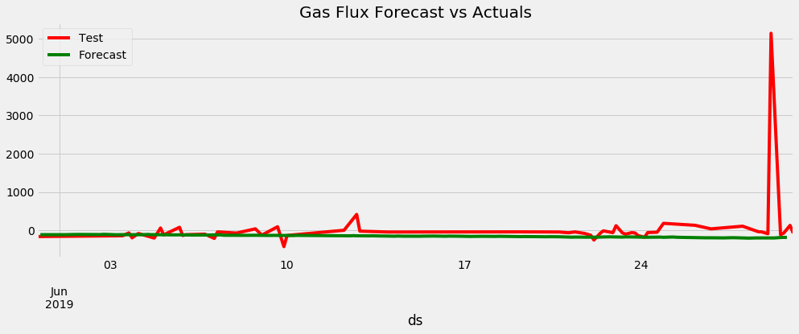

```python
df2=mergeddf_test_gasSTP

f, ax = plt.subplots(figsize=(14,5))
f.set_figheight(5)
f.set_figwidth(15)

df2.plot(kind='line', x='ds', y='y', color='red', label='Test', ax=ax)
forecast_data2.plot(kind='line',x='ds',y='yhat', color='green',label='Forecast', ax=ax)

plt.title('Gas Flux Forecast vs Actuals')
plt.show()
```

### Read the met data (Soil Parameters TDT) - the regressors to be added

```python
metData_SoilTDTParams = read_excel('../plotData/MetData_SoilParams_TDT_Filtered.xlsx', sheet_name='Sheet1')

metData_SoilTDTParams['ds'] = metData_SoilTDTParams['TIMESTAMP_1_rounded']

metData_SoilTDTParams.set_index('ds', drop=True, append=False, inplace=True, verify_integrity=False)
metData_SoilTDTParams.drop('TIMESTAMP_1_rounded', axis=1, inplace=True)
#metData_SoilTDTParams
```

| ds | TDT1_Ts_1_1_1 | TDT2_Ts_1_1_1 | TDT3_Ts_1_1_1 | TDT4_Ts_1_1_1 |
| --- | --- | --- | --- | --- |
| 2019-03-26 17:30:00 | 8.50 | 10.15 | 12.05 | 13.60 |
| 2019-03-26 18:00:00 | 8.50 | 10.25 | 11.80 | 12.55 |
| 2019-03-26 18:30:00 | 8.55 | 10.30 | 11.40 | 11.50 |
| 2019-03-26 19:00:00 | 8.65 | 10.30 | 10.95 | 10.70 |
| 2019-03-26 19:30:00 | 8.70 | 10.25 | 10.55 | 10.20 |
| ... | ... | ... | ... | ... |
| 2019-06-30 00:00:00 | 16.75 | 19.35 | 19.95 | 19.45 |
| 2019-06-30 00:30:00 | 16.80 | 19.25 | 19.65 | 19.10 |
| 2019-06-30 01:00:00 | 16.80 | 19.15 | 19.40 | 18.75 |
| 2019-06-30 01:30:00 | 16.80 | 19.00 | 19.15 | 18.45 |
| 2019-06-30 02:00:00 | 16.80 | 18.85 | 18.90 | 18.15 |

4494 rows × 4 columns

### Round the met data to the nearest hour to get matching timestamps with gas flux data

```python
plot_dataframe3 = metData_SoilTDTParams.copy()

plot_dataframe3['ds'] = metData_SoilTDTParams.index

#round the timestamp value to nearest half hour
plot_dataframe3['ds'] = plot_dataframe3['ds'].dt.round('1H')

#Create new index
plot_dataframe3.reset_index(drop=True, inplace=True)
plot_dataframe3.set_index('ds', drop=True, append=False, inplace=True, verify_integrity=False)

#plot_dataframe3
```

| ds | TDT1_Ts_1_1_1 | TDT2_Ts_1_1_1 | TDT3_Ts_1_1_1 | TDT4_Ts_1_1_1 |
| --- | --- | --- | --- | --- |
| 2019-03-26 18:00:00 | 8.50 | 10.15 | 12.05 | 13.60 |
| 2019-03-26 18:00:00 | 8.50 | 10.25 | 11.80 | 12.55 |
| 2019-03-26 18:00:00 | 8.55 | 10.30 | 11.40 | 11.50 |
| 2019-03-26 19:00:00 | 8.65 | 10.30 | 10.95 | 10.70 |
| 2019-03-26 20:00:00 | 8.70 | 10.25 | 10.55 | 10.20 |
| ... | ... | ... | ... | ... |
| 2019-06-30 00:00:00 | 16.75 | 19.35 | 19.95 | 19.45 |
| 2019-06-30 00:00:00 | 16.80 | 19.25 | 19.65 | 19.10 |
| 2019-06-30 01:00:00 | 16.80 | 19.15 | 19.40 | 18.75 |
| 2019-06-30 02:00:00 | 16.80 | 19.00 | 19.15 | 18.45 |
| 2019-06-30 02:00:00 | 16.80 | 18.85 | 18.90 | 18.15 |

4494 rows × 4 columns

### Resampling every 3 hour

```python
resample3        = plot_dataframe3.resample('3H')
daily_mean_flux3 = resample3.mean()

#print(daily_mean_flux3)
```

```
                     TDT1_Ts_1_1_1  TDT2_Ts_1_1_1  TDT3_Ts_1_1_1  \
ds
2019-03-26 18:00:00       8.621429      10.207143      10.992857
2019-03-26 21:00:00       8.870000       9.720000       9.180000
2019-03-27 00:00:00       8.914286       9.028571       7.807143
2019-03-27 03:00:00       8.890000       8.260000       6.760000
2019-03-27 06:00:00       8.742857       7.835714       6.764286
...                            ...            ...            ...
2019-06-29 12:00:00      15.700000      17.564286      20.757143
2019-06-29 15:00:00      15.830000      19.240000      23.440000
2019-06-29 18:00:00      16.200000      20.064286      22.878571
2019-06-29 21:00:00      16.550000      19.790000      21.150000
2019-06-30 00:00:00      16.775000      19.175000      19.550000

                     TDT4_Ts_1_1_1
ds
2019-03-26 18:00:00      11.150000
2019-03-26 21:00:00       8.470000
2019-03-27 00:00:00       6.664286
2019-03-27 03:00:00       6.040000
2019-03-27 06:00:00       6.507143
...                            ...
2019-06-29 12:00:00      24.321429
2019-06-29 15:00:00      26.520000
2019-06-29 18:00:00      23.407143
2019-06-29 21:00:00      20.900000
2019-06-30 00:00:00      18.941667

[763 rows x 4 columns]
```

### Merge the metdata together with the (gas flux) plot data

```python
metData_SoilTDTParams = daily_mean_flux3

metData_SoilTDTParams.to_csv('metdata-soilSTPparams.csv')
#metData_SoilTDTParams
```

| ds | TDT1_Ts_1_1_1 | TDT2_Ts_1_1_1 | TDT3_Ts_1_1_1 | TDT4_Ts_1_1_1 |
| --- | --- | --- | --- | --- |
| 2019-03-26 18:00:00 | 8.621429 | 10.207143 | 10.992857 | 11.150000 |
| 2019-03-26 21:00:00 | 8.870000 | 9.720000 | 9.180000 | 8.470000 |
| 2019-03-27 00:00:00 | 8.914286 | 9.028571 | 7.807143 | 6.664286 |
| 2019-03-27 03:00:00 | 8.890000 | 8.260000 | 6.760000 | 6.040000 |
| 2019-03-27 06:00:00 | 8.742857 | 7.835714 | 6.764286 | 6.507143 |
| ... | ... | ... | ... | ... |
| 2019-06-29 12:00:00 | 15.700000 | 17.564286 | 20.757143 | 24.321429 |
| 2019-06-29 15:00:00 | 15.830000 | 19.240000 | 23.440000 | 26.520000 |
| 2019-06-29 18:00:00 | 16.200000 | 20.064286 | 22.878571 | 23.407143 |
| 2019-06-29 21:00:00 | 16.550000 | 19.790000 | 21.150000 | 20.900000 |
| 2019-06-30 00:00:00 | 16.775000 | 19.175000 | 19.550000 | 18.941667 |

763 rows × 4 columns

```python
dfTDT = data.reset_index().rename(columns={'DateTime': 'ds', 'Flux': 'y'})
dfTDT.set_index('ds', drop=True, append=False, inplace=True, verify_integrity=False)
dfTDT.drop('index', axis=1, inplace=True)
#dfTDT
```

| ds | y |
| --- | --- |
| 2019-03-26 15:00:00 | -98.013000 |
| 2019-03-26 18:00:00 | -61.782600 |
| 2019-03-26 21:00:00 | -25.552200 |
| 2019-03-27 00:00:00 | -35.076767 |
| 2019-03-27 03:00:00 | -44.601333 |
| ... | ... |
| 2019-06-29 12:00:00 | -114.951200 |
| 2019-06-29 15:00:00 | -74.633900 |
| 2019-06-29 18:00:00 | 26.288600 |
| 2019-06-29 21:00:00 | 127.211100 |
| 2019-06-30 00:00:00 | -74.012900 |

764 rows × 1 columns

### Add Regressors to the model

```python
merged_df_TDT = dfTDT.merge(metData_SoilTDTParams, left_index=True, right_index=True, how='inner')

#merged_df_TDT
```

| ds | y | TDT1_Ts_1_1_1 | TDT2_Ts_1_1_1 | TDT3_Ts_1_1_1 | TDT4_Ts_1_1_1 |
| --- | --- | --- | --- | --- | --- |
| 2019-03-26 18:00:00 | -61.782600 | 8.621429 | 10.207143 | 10.992857 | 11.150000 |
| 2019-03-26 21:00:00 | -25.552200 | 8.870000 | 9.720000 | 9.180000 | 8.470000 |
| 2019-03-27 00:00:00 | -35.076767 | 8.914286 | 9.028571 | 7.807143 | 6.664286 |
| 2019-03-27 03:00:00 | -44.601333 | 8.890000 | 8.260000 | 6.760000 | 6.040000 |
| 2019-03-27 06:00:00 | -54.125900 | 8.742857 | 7.835714 | 6.764286 | 6.507143 |
| ... | ... | ... | ... | ... | ... |
| 2019-06-29 12:00:00 | -114.951200 | 15.700000 | 17.564286 | 20.757143 | 24.321429 |
| 2019-06-29 15:00:00 | -74.633900 | 15.830000 | 19.240000 | 23.440000 | 26.520000 |
| 2019-06-29 18:00:00 | 26.288600 | 16.200000 | 20.064286 | 22.878571 | 23.407143 |
| 2019-06-29 21:00:00 | 127.211100 | 16.550000 | 19.790000 | 21.150000 | 20.900000 |
| 2019-06-30 00:00:00 | -74.012900 | 16.775000 | 19.175000 | 19.550000 | 18.941667 |

763 rows × 5 columns

### Remove missing values

```python
merged_df_TDT.dropna(inplace=True)
```

#### Split the merged dataset into training and test set on Resampled Dataset

```python
#Train Test - split data
split_date = '31-May-2019'

mergeddf_train_gasTDT = merged_df_TDT.loc[merged_df_TDT.index <= split_date].copy()
mergeddf_test_gasTDT  = merged_df_TDT.loc[merged_df_TDT.index > split_date].copy()

mergeddf_train_gasTDT.reset_index(inplace=True)
mergeddf_test_gasTDT.reset_index(inplace=True)
```

```python
#mergeddf_train_gasTDT
```

|  | ds | y | TDT1_Ts_1_1_1 | TDT2_Ts_1_1_1 | TDT3_Ts_1_1_1 | TDT4_Ts_1_1_1 |
| --- | --- | --- | --- | --- | --- | --- |
| 0 | 2019-03-26 18:00:00 | -61.782600 | 8.621429 | 10.207143 | 10.992857 | 11.150000 |
| 1 | 2019-03-26 21:00:00 | -25.552200 | 8.870000 | 9.720000 | 9.180000 | 8.470000 |
| 2 | 2019-03-27 00:00:00 | -35.076767 | 8.914286 | 9.028571 | 7.807143 | 6.664286 |
| 3 | 2019-03-27 03:00:00 | -44.601333 | 8.890000 | 8.260000 | 6.760000 | 6.040000 |
| 4 | 2019-03-27 06:00:00 | -54.125900 | 8.742857 | 7.835714 | 6.764286 | 6.507143 |
| ... | ... | ... | ... | ... | ... | ... |
| 506 | 2019-05-30 12:00:00 | -167.516162 | 12.757143 | 14.657143 | 17.571429 | 20.757143 |
| 507 | 2019-05-30 15:00:00 | -166.850931 | 13.000000 | 15.860000 | 19.040000 | 21.030000 |
| 508 | 2019-05-30 18:00:00 | -166.185700 | 13.328571 | 16.264286 | 18.214286 | 18.392857 |
| 509 | 2019-05-30 21:00:00 | -165.520469 | 13.640000 | 15.840000 | 16.270000 | 15.710000 |
| 510 | 2019-05-31 00:00:00 | -164.855238 | 13.778571 | 15.150000 | 15.114286 | 14.807143 |

511 rows × 6 columns

### Create Prophet model

```python
pro_regressorTDT = Prophet()  #add tuning parameters later
pro_regressorTDT.add_regressor('TDT1_Ts_1_1_1')
pro_regressorTDT.add_regressor('TDT2_Ts_1_1_1')
pro_regressorTDT.add_regressor('TDT3_Ts_1_1_1')
pro_regressorTDT.add_regressor('TDT4_Ts_1_1_1')

#Fitting the data
pro_regressorTDT.fit(mergeddf_train_gasTDT)

#forecast the data for Test  data
forecast_dataTDT = pro_regressorTDT.predict(mergeddf_test_gasTDT)
```

```
INFO:fbprophet:Disabling yearly seasonality. Run prophet with yearly_seasonality=True to override this.
```

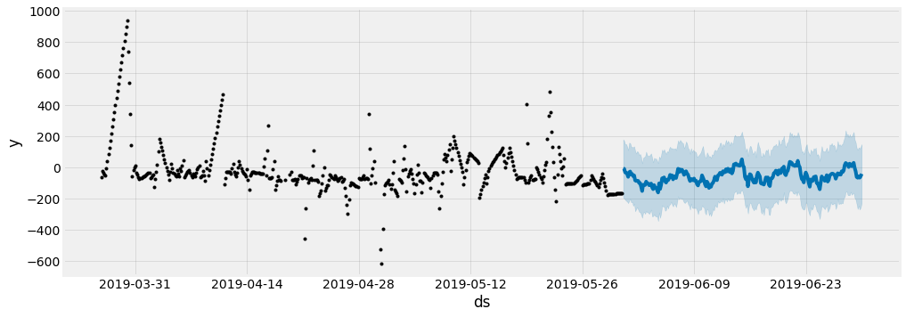

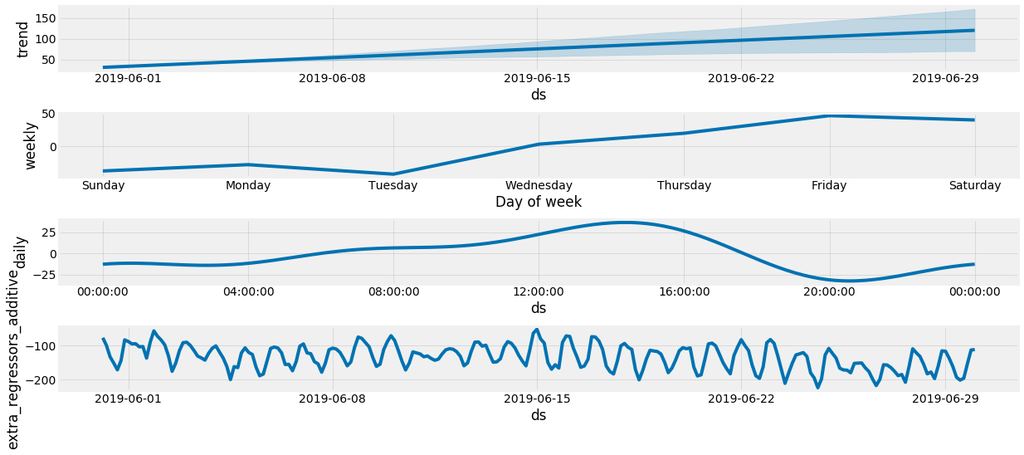

```python
fig21 = pro_regressorTDT.plot(forecast_dataTDT);
fig22 = pro_regressorTDT.plot_components(forecast_dataTDT)

fig21.set_figheight(5)
fig21.set_figwidth(15)

fig22.set_figheight(7)
fig22.set_figwidth(19)
```

### Measure the performance of the model

```python
mape = mean_absolute_percentage_error(mergeddf_test_gasTDT['y'],forecast_dataTDT['yhat'])
print("MAPE",round(mape,4))
```

```
MAPE 261.4368
```

### Compare the gas flux in test set and in forecasted set

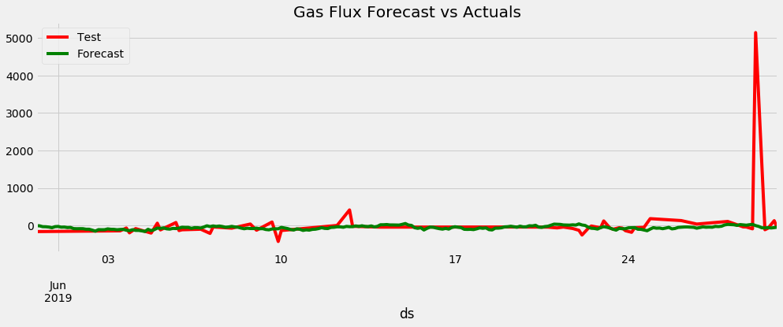

```python
df2=mergeddf_test_gasTDT

f, ax = plt.subplots(figsize=(14,5))
f.set_figheight(5)
f.set_figwidth(15)

df2.plot(kind='line', x='ds', y='y', color='red', label='Test', ax=ax)
forecast_dataTDT.plot(kind='line',x='ds',y='yhat', color='green',label='Forecast', ax=ax)

plt.title('Gas Flux Forecast vs Actuals')
plt.show()
```

### Read the met data (Volumetric Water Content Parameters) - the regressors to be added

```python
metData_VWCParams = read_excel('../plotData/MetData_VolumetricWaterContent_VWC_Filtered.xlsx', sheet_name='Sheet1')

metData_VWCParams['ds'] = metData_VWCParams['TIMESTAMP_1_rounded']

metData_VWCParams.set_index('ds', drop=True, append=False, inplace=True, verify_integrity=False)
metData_VWCParams.drop('TIMESTAMP_1_rounded', axis=1, inplace=True)
#metData_VWCParams
```

| ds | VWC_1_1_1 | VWC_2_1_1 | VWC_3_1_1 | VWC_4_1_1 |
| --- | --- | --- | --- | --- |
| 2019-03-26 17:30:00 | 18.60 | 27.75 | 30.25 | 36.05 |
| 2019-03-26 18:00:00 | 18.60 | 27.70 | 30.35 | 35.95 |
| 2019-03-26 18:30:00 | 18.60 | 27.75 | 30.45 | 35.90 |
| 2019-03-26 19:00:00 | 18.60 | 27.80 | 30.35 | 35.85 |
| 2019-03-26 19:30:00 | 18.60 | 27.75 | 30.35 | 35.80 |
| ... | ... | ... | ... | ... |
| 2019-06-30 00:00:00 | 12.85 | 19.30 | 20.35 | 24.90 |
| 2019-06-30 00:30:00 | 12.80 | 19.30 | 20.20 | 24.90 |
| 2019-06-30 01:00:00 | 12.80 | 19.25 | 20.20 | 24.85 |
| 2019-06-30 01:30:00 | 12.85 | 19.25 | 20.40 | 24.85 |
| 2019-06-30 02:00:00 | 12.90 | 19.30 | 20.30 | 24.85 |

4494 rows × 4 columns

### Round the met data to the nearest hour to get matching timestamps with gas flux data

```python
plot_dataframe4 = metData_VWCParams.copy()
plot_dataframe4['ds'] = metData_VWCParams.index

#round the timestamp value to nearest half hour
plot_dataframe4['ds'] = plot_dataframe4['ds'].dt.round('1H')

#Create new index
plot_dataframe4.reset_index(drop=True, inplace=True)
plot_dataframe4.set_index('ds', drop=True, append=False, inplace=True, verify_integrity=False)

#plot_dataframe4
```

| ds | VWC_1_1_1 | VWC_2_1_1 | VWC_3_1_1 | VWC_4_1_1 |
| --- | --- | --- | --- | --- |
| 2019-03-26 18:00:00 | 18.60 | 27.75 | 30.25 | 36.05 |
| 2019-03-26 18:00:00 | 18.60 | 27.70 | 30.35 | 35.95 |
| 2019-03-26 18:00:00 | 18.60 | 27.75 | 30.45 | 35.90 |
| 2019-03-26 19:00:00 | 18.60 | 27.80 | 30.35 | 35.85 |
| 2019-03-26 20:00:00 | 18.60 | 27.75 | 30.35 | 35.80 |
| ... | ... | ... | ... | ... |
| 2019-06-30 00:00:00 | 12.85 | 19.30 | 20.35 | 24.90 |
| 2019-06-30 00:00:00 | 12.80 | 19.30 | 20.20 | 24.90 |
| 2019-06-30 01:00:00 | 12.80 | 19.25 | 20.20 | 24.85 |
| 2019-06-30 02:00:00 | 12.85 | 19.25 | 20.40 | 24.85 |
| 2019-06-30 02:00:00 | 12.90 | 19.30 | 20.30 | 24.85 |

4494 rows × 4 columns

### Resampling every 3 hour

```python
resample4        = plot_dataframe4.resample('3H')
daily_mean_flux4 = resample4.mean()
#print(daily_mean_flux4)
```

```
                     VWC_1_1_1  VWC_2_1_1  VWC_3_1_1  VWC_4_1_1
ds
2019-03-26 18:00:00  18.600000  27.728571  30.328571  35.878571
2019-03-26 21:00:00  18.810000  27.530000  30.250000  35.770000
2019-03-27 00:00:00  18.635714  27.500000  30.228571  35.714286
2019-03-27 03:00:00  18.930000  27.500000  30.180000  35.650000
2019-03-27 06:00:00  18.992857  27.471429  30.014286  35.642857
...                        ...        ...        ...        ...
2019-06-29 12:00:00  13.028571  19.714286  21.292857  26.407143
2019-06-29 15:00:00  12.860000  19.420000  21.130000  25.800000
2019-06-29 18:00:00  12.857143  19.300000  20.714286  25.285714
2019-06-29 21:00:00  12.870000  19.300000  20.370000  25.020000
2019-06-30 00:00:00  12.841667  19.283333  20.266667  24.875000

[763 rows x 4 columns]
```

### Merge the Volumetric Water Content metdata together with the (gas flux) plot data

```python
metData_VWCParams = daily_mean_flux4
```

```python
metData_VWCParams.to_csv('metdata-vwcparams1.csv')
#metData_VWCParams
```

| ds | VWC_1_1_1 | VWC_2_1_1 | VWC_3_1_1 | VWC_4_1_1 |
| --- | --- | --- | --- | --- |
| 2019-03-26 18:00:00 | 18.600000 | 27.728571 | 30.328571 | 35.878571 |
| 2019-03-26 21:00:00 | 18.810000 | 27.530000 | 30.250000 | 35.770000 |
| 2019-03-27 00:00:00 | 18.635714 | 27.500000 | 30.228571 | 35.714286 |
| 2019-03-27 03:00:00 | 18.930000 | 27.500000 | 30.180000 | 35.650000 |
| 2019-03-27 06:00:00 | 18.992857 | 27.471429 | 30.014286 | 35.642857 |
| ... | ... | ... | ... | ... |
| 2019-06-29 12:00:00 | 13.028571 | 19.714286 | 21.292857 | 26.407143 |
| 2019-06-29 15:00:00 | 12.860000 | 19.420000 | 21.130000 | 25.800000 |
| 2019-06-29 18:00:00 | 12.857143 | 19.300000 | 20.714286 | 25.285714 |
| 2019-06-29 21:00:00 | 12.870000 | 19.300000 | 20.370000 | 25.020000 |
| 2019-06-30 00:00:00 | 12.841667 | 19.283333 | 20.266667 | 24.875000 |

763 rows × 4 columns

```python
dfV = data.reset_index().rename(columns={'DateTime': 'ds', 'Flux': 'y'})
dfV.set_index('ds', drop=True, append=False, inplace=True, verify_integrity=False)
dfV.drop('index', axis=1, inplace=True)
#dfV
```

| ds | y |
| --- | --- |
| 2019-03-26 15:00:00 | -98.013000 |
| 2019-03-26 18:00:00 | -61.782600 |
| 2019-03-26 21:00:00 | -25.552200 |
| 2019-03-27 00:00:00 | -35.076767 |
| 2019-03-27 03:00:00 | -44.601333 |
| ... | ... |
| 2019-06-29 12:00:00 | -114.951200 |
| 2019-06-29 15:00:00 | -74.633900 |
| 2019-06-29 18:00:00 | 26.288600 |
| 2019-06-29 21:00:00 | 127.211100 |
| 2019-06-30 00:00:00 | -74.012900 |

764 rows × 1 columns

```python
merged_df_Vwc = dfV.merge(metData_VWCParams, left_index=True, right_index=True, how='inner')

#merged_df_Vwc
```

| ds | y | VWC_1_1_1 | VWC_2_1_1 | VWC_3_1_1 | VWC_4_1_1 |
| --- | --- | --- | --- | --- | --- |
| 2019-03-26 18:00:00 | -61.782600 | 18.600000 | 27.728571 | 30.328571 | 35.878571 |
| 2019-03-26 21:00:00 | -25.552200 | 18.810000 | 27.530000 | 30.250000 | 35.770000 |
| 2019-03-27 00:00:00 | -35.076767 | 18.635714 | 27.500000 | 30.228571 | 35.714286 |
| 2019-03-27 03:00:00 | -44.601333 | 18.930000 | 27.500000 | 30.180000 | 35.650000 |
| 2019-03-27 06:00:00 | -54.125900 | 18.992857 | 27.471429 | 30.014286 | 35.642857 |
| ... | ... | ... | ... | ... | ... |
| 2019-06-29 12:00:00 | -114.951200 | 13.028571 | 19.714286 | 21.292857 | 26.407143 |
| 2019-06-29 15:00:00 | -74.633900 | 12.860000 | 19.420000 | 21.130000 | 25.800000 |
| 2019-06-29 18:00:00 | 26.288600 | 12.857143 | 19.300000 | 20.714286 | 25.285714 |
| 2019-06-29 21:00:00 | 127.211100 | 12.870000 | 19.300000 | 20.370000 | 25.020000 |
| 2019-06-30 00:00:00 | -74.012900 | 12.841667 | 19.283333 | 20.266667 | 24.875000 |

763 rows × 5 columns

### Add Regressors to the model

#### Split the merged dataset into training and test set on Resampled Dataset

```python
#Train Test - split data
split_date = '31-May-2019'   #'30-April-2019'

#dataf = daily_mean_flux

mergeddf_train_gasVwc = merged_df_Vwc.loc[merged_df_Vwc.index <= split_date].copy()
mergeddf_test_gasVwc  = merged_df_Vwc.loc[merged_df_Vwc.index > split_date].copy()

mergeddf_train_gasVwc.reset_index(inplace=True)
mergeddf_test_gasVwc.reset_index(inplace=True)
```

### Remove missing values

```python
mergeddf_train_gasVwc.dropna(inplace=True)
mergeddf_test_gasVwc.dropna(inplace=True)
```

```python
#mergeddf_test_gasVwc
```

|  | ds | y | VWC_1_1_1 | VWC_2_1_1 | VWC_3_1_1 | VWC_4_1_1 |
| --- | --- | --- | --- | --- | --- | --- |
| 0 | 2019-05-31 03:00:00 | -164.190008 | 12.400000 | 17.200000 | 17.010000 | 20.660000 |
| 1 | 2019-05-31 06:00:00 | -163.524777 | 12.650000 | 17.121429 | 16.757143 | 20.685714 |
| 2 | 2019-05-31 09:00:00 | -162.859546 | 12.930000 | 17.090000 | 17.020000 | 20.780000 |
| 3 | 2019-05-31 12:00:00 | -162.194315 | 12.357143 | 17.200000 | 17.214286 | 20.935714 |
| 4 | 2019-05-31 15:00:00 | -161.529085 | 12.400000 | 17.040000 | 17.310000 | 20.810000 |
| ... | ... | ... | ... | ... | ... | ... |
| 235 | 2019-06-29 12:00:00 | -114.951200 | 13.028571 | 19.714286 | 21.292857 | 26.407143 |
| 236 | 2019-06-29 15:00:00 | -74.633900 | 12.860000 | 19.420000 | 21.130000 | 25.800000 |
| 237 | 2019-06-29 18:00:00 | 26.288600 | 12.857143 | 19.300000 | 20.714286 | 25.285714 |
| 238 | 2019-06-29 21:00:00 | 127.211100 | 12.870000 | 19.300000 | 20.370000 | 25.020000 |
| 239 | 2019-06-30 00:00:00 | -74.012900 | 12.841667 | 19.283333 | 20.266667 | 24.875000 |

240 rows × 6 columns

```python
merged_df_Vwc.to_excel('ch4_vwcparams_3h.xlsx')
```

### Create Prophet model

```python
pro_regressorV = Prophet()  #add tuning parameters later
pro_regressorV.add_regressor('VWC_1_1_1')
pro_regressorV.add_regressor('VWC_2_1_1')
pro_regressorV.add_regressor('VWC_3_1_1')
pro_regressorV.add_regressor('VWC_4_1_1')

#Fitting the data
pro_regressorV.fit(mergeddf_train_gasVwc)

#future_data = pro_regressor.make_future_dataframe(periods=14, freq='D')

#forecast the data for Test  data
forecast_dataV = pro_regressorV.predict(mergeddf_test_gasVwc)
```

```
INFO:fbprophet:Disabling yearly seasonality. Run prophet with yearly_seasonality=True to override this.
```

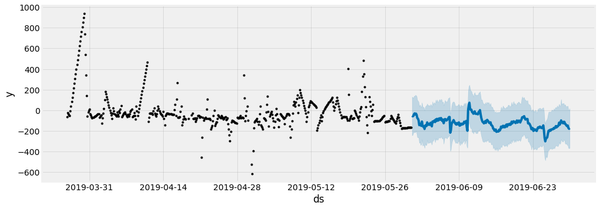

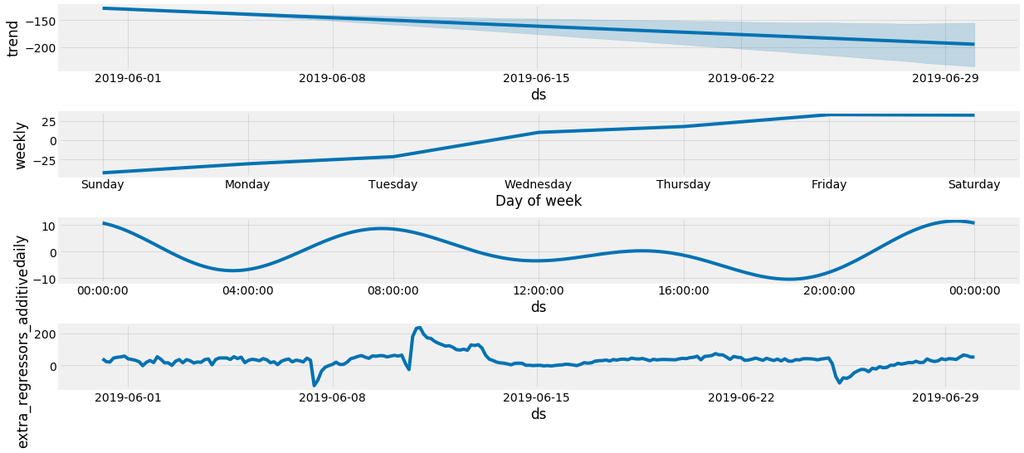

```python
fig21 = pro_regressorV.plot(forecast_dataV);
fig22 = pro_regressorV.plot_components(forecast_dataV)

fig21.set_figheight(5)
fig21.set_figwidth(15)

fig22.set_figheight(7)
fig22.set_figwidth(19)
```

### Measure the performance of the model

```python
mape = mean_absolute_percentage_error(mergeddf_test_gasVwc['y'],forecast_dataV['yhat'])
print("MAPE",round(mape,4))
```

```
MAPE 369.56
```

### Compare the gas flux in test set and in forecasted set

[figure not shown]

```python
#pd.plotting.register_matplotlib_converters()

df4 = mergeddf_test_gasVwc

f, ax = plt.subplots(figsize=(14,5))
f.set_figheight(5)
f.set_figwidth(15)

df4.plot(kind='line', x='ds', y='y', color='red', label='Test', ax=ax)
forecast_dataV.plot(kind='line',x='ds',y='yhat', color='green',label='Forecast', ax=ax)

plt.title('Gas Flux Forecast vs Actuals')
plt.show()
```

### Hide code for printing/visualising purposes

```python
from IPython.display import HTML

HTML('''<script>
code_show=true;
function code_toggle() {
 if (code_show){
 $('div.input').hide();
 } else {
 $('div.input').show();
 }
 code_show = !code_show
}
$( document ).ready(code_toggle);
</script>
<form action="javascript:code_toggle()"><input type="submit" value="Click here to toggle on/off the raw code."></form>''')
```